# Customer Personality Analysis

May 2026

## The problem & the goal

#### Business problem

A retail company sends the same offer to all customers without any targeting. This wastes budget on people who won’t convert and misses those most likely to buy.

#### Two-part approach

**Part 1:** PCA + K-Means to find natural customer segments.  
**Part 2:** Four classification models to predict who will accept the next campaign.

2,240 customers

29 variables

~15% positive response rate

5 past campaigns

Cross-sectional dataset. One row per customer, iid. Mixed types: numeric, categorical, binary.

## Dataset: Variable groups & features

#### Demographics & Household

Core customer profiling attributes used to establish baseline socioeconomic status.

Age Income Education Marital_Status Kidhome Teenhome

#### Product Spending Profile

Two-year historical spend data across six primary retail categories. Aggregated into a master **TotalSpent** feature to represent absolute buying power.

Wines Fruits Meat Fish Sweets Gold

#### Channel Engagement & Traffic

Interaction metrics detailing exactly how the customer shops. Separating visits from purchases is critical to identify browsers.

- **NumWebVisitsMonth:** Digital traffic proxy
- **NumWebPurchases:** E-commerce conversion
- **NumStorePurchases:** Physical retail
- **NumCatalogPurchases:** Direct mail

#### Campaign History & The Target

Historical record of promotional acceptance across 5 previous marketing initiatives.

**Target:** `ResponseTarget` (Yes/No). Encodes acceptance of campaign 6 and is the label for all supervised models.

**Feature Engineering:** Raw dates (`Year_Birth`) were transformed into `Age` for compatibility with distance-based algorithms.

## Data Cleaning: Ensuring Result Integrity

#### 1 Handling Missing Values

Rows without income data were removed to prevent estimation bias. Imputation was avoided as it could introduce artificial signals in financial modeling.

Removed: Income (NA)

#### 2 Outlier Suppression

Strict filtering to stabilize variance. We capped Age at 100 and Income at 600k to remove obvious data-entry errors.

Filtered: Age > 100 Filtered: Income > 600k

#### 3 Zero-Variance Features

Variables with constant values across all observations provide zero predictive power. Their removal reduces computational noise.

Dropped: Z_CostContact Dropped: Z_Revenue

#### 4 Administrative Noise

Row identifiers and join dates were excluded to prevent models from learning coincidental patterns.

Dropped: ID Dropped: Dt_Customer

**Rationale:** The cleaning phase focused on improving the signal-to-noise ratio. By prioritising data quality over quantity, we ensure that the subsequent PCA and predictive models are grounded in realistic behavioural patterns.

## Part 1: Unsupervised Learning

## PCA: Visual Interpretation & Biplot

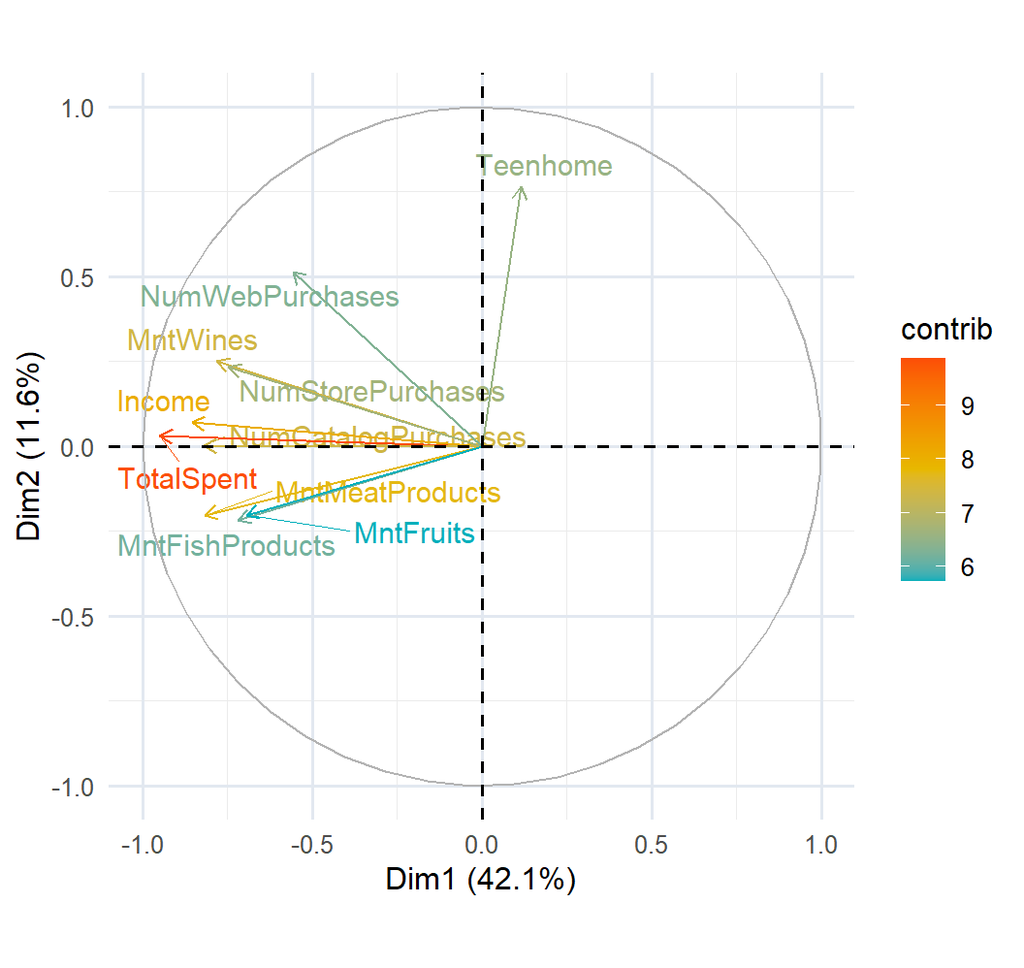

#### PC2: Family Structure (11.6%)

`Teenhome` loads heavily on PC2, capturing a household dimension independent of raw income.

Segmentation relies heavily on spending levels, visually confirmed by the dominant PC1 axis.

## Clustering: Choosing optimal k

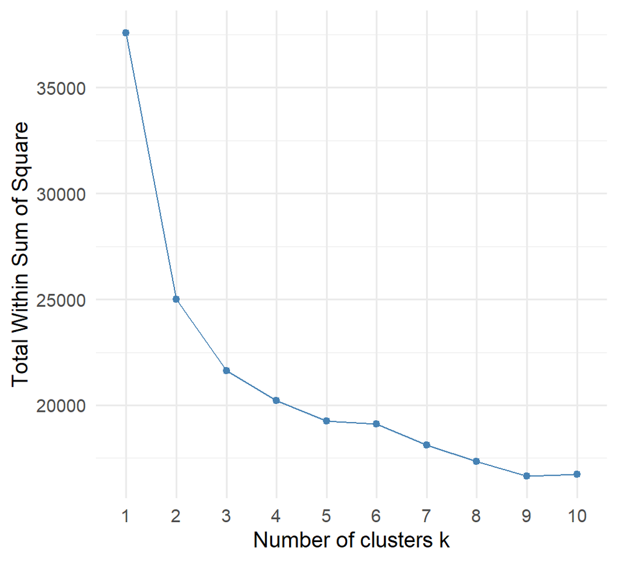

#### The Elbow Method

Evaluating the Within-Cluster Sum of Squares reveals a clear bend at **k = 3**.

#### Why stop at 3?

Increasing the number of clusters beyond 3 flattens the curve, meaning we would add complexity without capturing fundamentally different consumer behaviours.

## Hierarchical Dendrogram: Structure Validation

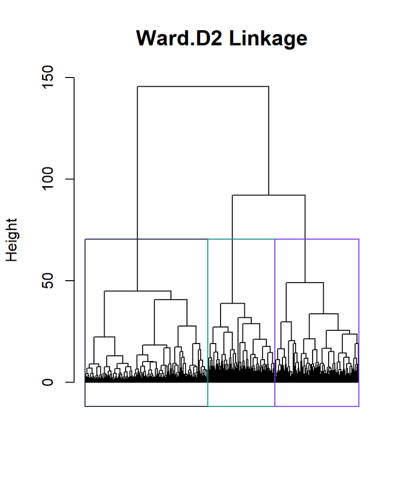

#### Structural Confirmation

The hierarchical approach validates our K-Means setup. The dendrogram naturally splits into three distinct main branches.

#### High Stability

The large vertical gap between the 3-cluster split and the subsequent lower splits confirms that the chosen partition is robust and deeply rooted in the data.

## Cluster Profiles: The Three Customer Tiers

| Segment | N | Avg Income (€) | Avg Total Spent (€) | Avg Recency (days) | Avg Web Visits/mo |
| --- | --- | --- | --- | --- | --- |
| Premium | 583 | 75880 | 1389 | 50.0 | 2.9 |
| Middle | 614 | 57907 | 711 | 47.8 | 5.7 |
| Browsers | 1015 | 34620 | 96 | 49.2 | 6.5 |

#### Premium Segment

Highest income and maximum total spend. They engage less with the website but convert at high values.

#### Browser Segment

Lowest absolute spend, but highest web visits. Represents a pool of latent value requiring conversion strategies.

## Cluster Deep Dive: Marketing Implications

#### Middle: the treat-them-right tier

Balanced basket across categories. They use both web and store. Moderate recency: regular but not impulsive.

#### Browsers are more than clicks

They visit the site a lot but almost never buy. Their income is not zero, so price is not the only barrier. They might need trust or a simpler first step.

#### From segments to strategy

**Premium:** early access, VIP events.  
**Middle:** bundle deals, cross-sell.  
**Browsers:** free shipping on first order, low-risk trial.

**Key insight:** Web visits are negatively correlated with spending. So heavy site traffic is not a sales signal; it often flags people who are still comparing or window‑shopping.

## Part 2: Supervised Learning

## Setup

**Target Variable:** `ResponseTarget` (binary Yes/No), indicating campaign 6 acceptance.

**Class imbalance:** ~15% positive responses. AUC‑ROC was strictly chosen as the evaluation metric to prevent misleading accuracy scores.

#### 5-fold cross-validation

Performed only on the training set (80% of data). Each fold is used once as validation. Prevents overfitting and provides stable AUC estimates before touching the holdout set.

80% training (with CV)

20% final test

#### Models evaluated

Logistic regression

Lasso

Random Forest

Artificial Neural Network (ANN)

Stratified split keeps the ~15% Yes rate equal in train and test. Random Forest and ANN were tuned with CV; Logistic/Lasso used CV+upsampling.

## Random forest result: Drivers of Conversion

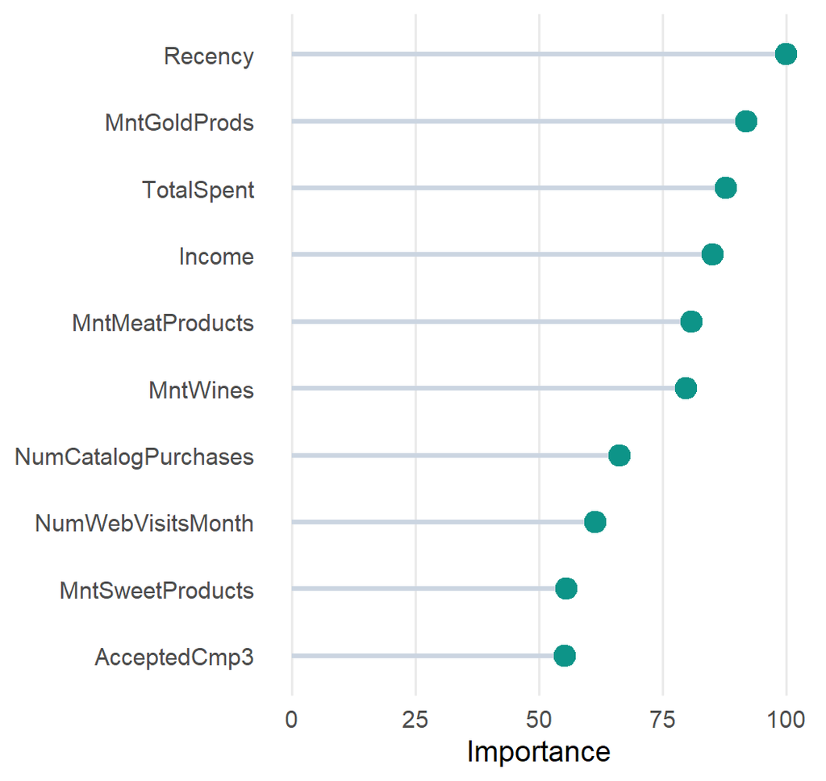

#### Recency is #1

Days since last purchase dominates. Recent buyers are drastically more likely to convert.

## Model Comparison: 5-Fold CV AUC-ROC

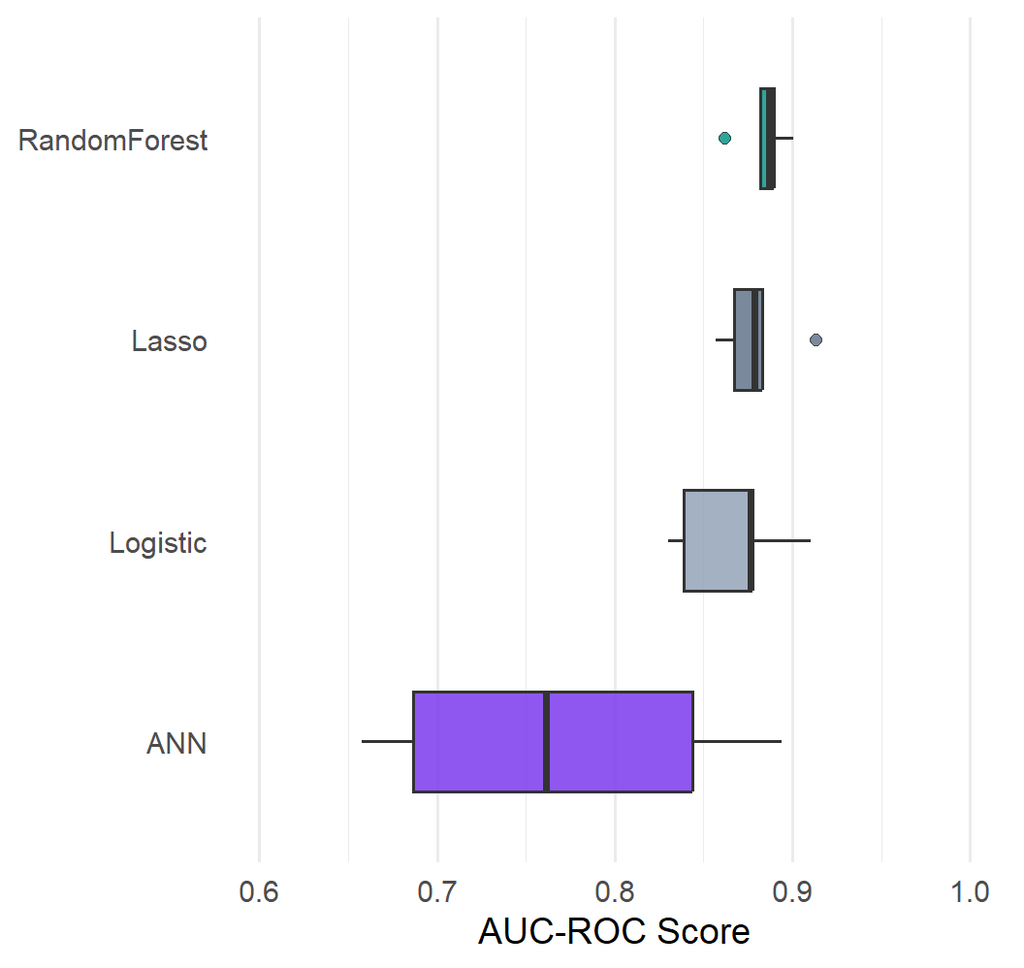

#### Random Forest Wins

Highest median AUC and the tightest interquartile range across folds, proving to be the most accurate and consistent model.

#### ANN is Unstable

Shows much higher fold-to-fold variance and the lowest mean, making it less reliable in production.

## Test Set Evaluation: Threshold 0.5 vs 0.3

#### Default Threshold (0.5)

Highly specific but far too conservative. We accurately identify non‑buyers but capture only 52% of actual converters.

|  | Predicted No | Predicted Yes |
| --- | --- | --- |
| **Actual No** | 362 | 13 |
| **Actual Yes** | 32 | 34 |

Sensitivity: 0.52 Specificity: 0.97

#### Optimized Threshold (0.3)

|  | Predicted No | Predicted Yes |
| --- | --- | --- |
| **Actual No** | 295 | 80 |
| **Actual Yes** | 12 | 54 |

Sensitivity: 0.82 Specificity: 0.79

**Business Logic:** Sending a digital offer costs essentially zero. Accepting more false positives to catch real converters maximises ROI.

## Key takeaways

#### 01: Ditch the blanket approach

Clustering reveals three economically distinct tiers. Segment‑specific strategies are the logical baseline, targeting Premium buyers and Browsers with different incentives.

#### 02: Behaviour predicts conversion better than demographics

Recency and past campaign acceptance are far stronger predictors than age or marital status. Marketing efforts must prioritise recent engagement signals.

#### 03: Threshold tuning guarantees ROI

Deployed at an adjusted threshold of 0.3, the Random Forest model becomes a cost‑effective screening tool that recovers a large share of potential revenue with minimal overhead.